# IODS course project

### Principal component analysis (PCA)

PCA is a methon in which reduces any number of measured (continuous) and correlated variables into few uncorrelated components that collect as much variance as possible. Important components can be then used to analyse the phenomenon without the unrelated dimensions.

#### PCA on raw data

```r
#perform a PCA on the raw human data
pca_human_raw <- prcomp(human)

#summary
summary(human)
```

```
##     Edu2.FM          Labo.FM          Edu.Exp         Life.Exp
##  Min.   :0.1717   Min.   :0.1857   Min.   : 5.40   Min.   :49.00
##  1st Qu.:0.7264   1st Qu.:0.5984   1st Qu.:11.25   1st Qu.:66.30
##  Median :0.9375   Median :0.7535   Median :13.50   Median :74.20
##  Mean   :0.8529   Mean   :0.7074   Mean   :13.18   Mean   :71.65
##  3rd Qu.:0.9968   3rd Qu.:0.8535   3rd Qu.:15.20   3rd Qu.:77.25
##  Max.   :1.4967   Max.   :1.0380   Max.   :20.20   Max.   :83.50
##       GNI            Mat.Mor         Ado.Birth         Parli.F
##  Min.   :   581   Min.   :   1.0   Min.   :  0.60   Min.   : 0.00
##  1st Qu.:  4198   1st Qu.:  11.5   1st Qu.: 12.65   1st Qu.:12.40
##  Median : 12040   Median :  49.0   Median : 33.60   Median :19.30
##  Mean   : 17628   Mean   : 149.1   Mean   : 47.16   Mean   :20.91
##  3rd Qu.: 24512   3rd Qu.: 190.0   3rd Qu.: 71.95   3rd Qu.:27.95
##  Max.   :123124   Max.   :1100.0   Max.   :204.80   Max.   :57.50
```

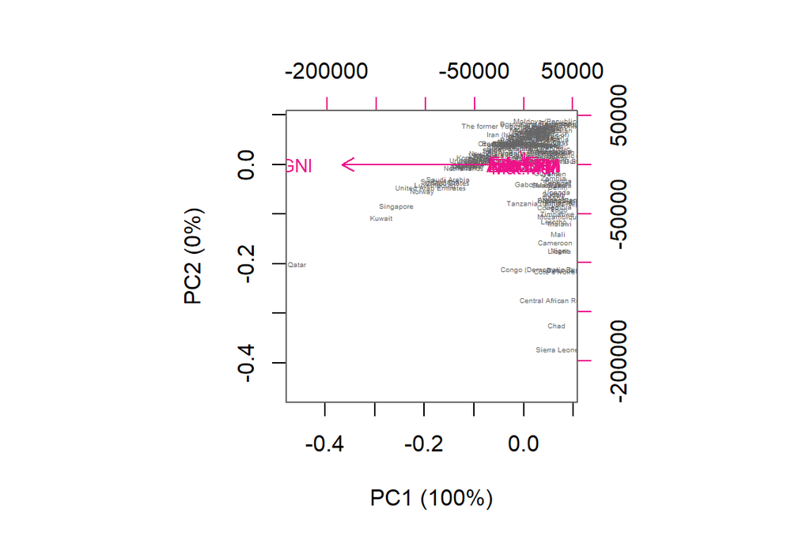

```r
#creating labels with rounded PC's
pca_perc_raw <- round(100*summary(pca_human_raw)$importance[2, ], digits =1)
pc_lab_raw = paste0(names(pca_perc_raw), " (", pca_perc_raw, "%)")


# draw a biplot of RAW data
biplot(pca_human_raw, choices = 1:2, cex = c(0.3, 0.8), col = c("grey40", "deeppink2"), xlab = pc_lab_raw[1], ylab = pc_lab_raw[2])
```

Due to the variables varying (from Labo.FM’s min-max of 0.1857-1.0380 to GNI’s 581-123124) so much in the raw data it’s hard to draw any conclusion from the plot

#### PCA on standardized data

```r
# standardize the variables
human_std <- scale(human)

#summary
summary(human_std)
```

```
##     Edu2.FM           Labo.FM           Edu.Exp           Life.Exp
##  Min.   :-2.8189   Min.   :-2.6247   Min.   :-2.7378   Min.   :-2.7188
##  1st Qu.:-0.5233   1st Qu.:-0.5484   1st Qu.:-0.6782   1st Qu.:-0.6425
##  Median : 0.3503   Median : 0.2316   Median : 0.1140   Median : 0.3056
##  Mean   : 0.0000   Mean   : 0.0000   Mean   : 0.0000   Mean   : 0.0000
##  3rd Qu.: 0.5958   3rd Qu.: 0.7350   3rd Qu.: 0.7126   3rd Qu.: 0.6717
##  Max.   : 2.6646   Max.   : 1.6632   Max.   : 2.4730   Max.   : 1.4218
##       GNI             Mat.Mor          Ado.Birth          Parli.F
##  Min.   :-0.9193   Min.   :-0.6992   Min.   :-1.1325   Min.   :-1.8203
##  1st Qu.:-0.7243   1st Qu.:-0.6496   1st Qu.:-0.8394   1st Qu.:-0.7409
##  Median :-0.3013   Median :-0.4726   Median :-0.3298   Median :-0.1403
##  Mean   : 0.0000   Mean   : 0.0000   Mean   : 0.0000   Mean   : 0.0000
##  3rd Qu.: 0.3712   3rd Qu.: 0.1932   3rd Qu.: 0.6030   3rd Qu.: 0.6127
##  Max.   : 5.6890   Max.   : 4.4899   Max.   : 3.8344   Max.   : 3.1850
```

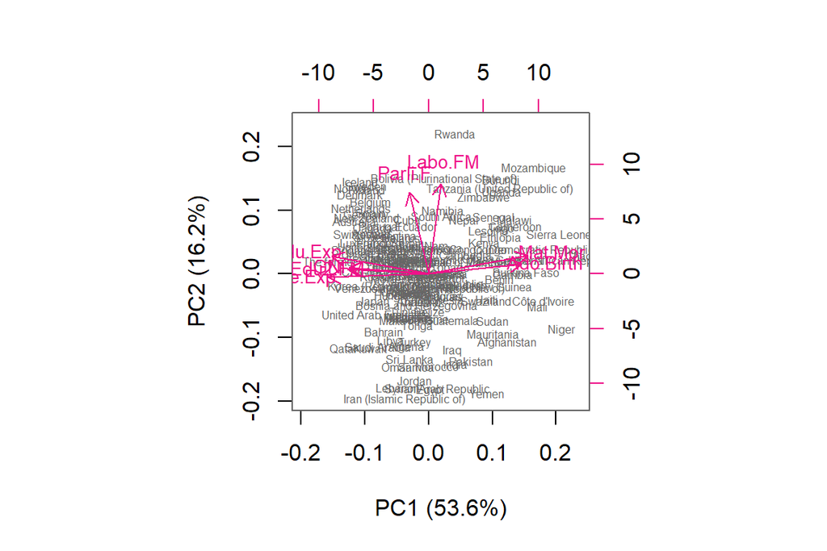

```r
# perform a PCA on the standardized data
pca_human_std <- prcomp(human_std)

#creating labels with rounded PC's
pca_perc_std <- round(100*summary(pca_human_std)$importance[2, ], digits =1)
pc_lab_std = paste0(names(pca_perc_std), " (", pca_perc_std, "%)")

# draw a biplot of standardized data
biplot(pca_human_std, choices = 1:2, cex = c(0.5, 0.8), col = c("grey40", "deeppink2"),  xlab = pc_lab_std[1], ylab = pc_lab_std[2])
```

With the data standardized (mean=0, standard deviation=1) it should be easier to compare the variables.

#### Interpretation of results

The X-label and Y-labels shows us the PC1 and PC2 scores. Due to the raw data’s high numeric differences the raw data plot is pretty much unreadable. With standardized we got 53.6% and 16.2% respectively.

The angles between vectors/arrows can be interpreted as the correlations between variables. When variable vectors have a roughly 90 degree angle it means they’re not likely to be correlated such as LAbo.FM and Life.Exp. If vectors are close to each other it means that they’re positively correlated such as maternal mortality and adolescent birth rate. GNI, Edu.Exp, Life.Exp and Edu2.FM are positively correlated with each other. If vectors are in a 180 degree angle of each other it means that they’re negatively correlated like the previously mentioned (GNI, Edu.Exp, Life.Exp and Edu2.FM) are negatively correlated to Mat.Mor and Ado.Birth. The angle between a variable vector and PC axis can be interpreted in same fashion.

Overall the vectors can be divided into 3 clusters: - Edu.Exp, GNI, Edu2.FM and Life.Exp - Mat.Mor and Ado.Birth - Parli.F and Labo.FM

### Multiple correspondence analysis (MCA)

Multiple correspondence analysis is a similar method to PCA but makes it possible to reduce dimensions in variables that are discrete or even nominal which by finding suitable continous scales for them.

We’ll look into tea data from FactoMineR package. It’s a questionnaire made for 300 individuals about their tea drinking habits and perceptions.

```r
tea <- read.csv("https://raw.githubusercontent.com/KimmoVehkalahti/Helsinki-Open-Data-Science/master/datasets/tea.csv", stringsAsFactors = TRUE)

View(tea)

str(tea)
```

```
## 'data.frame':    300 obs. of  36 variables:
##  $ breakfast       : Factor w/ 2 levels "breakfast","Not.breakfast": 1 1 2 2 1 2 1 2 1 1 ...
##  $ tea.time        : Factor w/ 2 levels "Not.tea time",..: 1 1 2 1 1 1 2 2 2 1 ...
##  $ evening         : Factor w/ 2 levels "evening","Not.evening": 2 2 1 2 1 2 2 1 2 1 ...
##  $ lunch           : Factor w/ 2 levels "lunch","Not.lunch": 2 2 2 2 2 2 2 2 2 2 ...
##  $ dinner          : Factor w/ 2 levels "dinner","Not.dinner": 2 2 1 1 2 1 2 2 2 2 ...
##  $ always          : Factor w/ 2 levels "always","Not.always": 2 2 2 2 1 2 2 2 2 2 ...
##  $ home            : Factor w/ 2 levels "home","Not.home": 1 1 1 1 1 1 1 1 1 1 ...
##  $ work            : Factor w/ 2 levels "Not.work","work": 1 1 2 1 1 1 1 1 1 1 ...
##  $ tearoom         : Factor w/ 2 levels "Not.tearoom",..: 1 1 1 1 1 1 1 1 1 2 ...
##  $ friends         : Factor w/ 2 levels "friends","Not.friends": 2 2 1 2 2 2 1 2 2 2 ...
##  $ resto           : Factor w/ 2 levels "Not.resto","resto": 1 1 2 1 1 1 1 1 1 1 ...
##  $ pub             : Factor w/ 2 levels "Not.pub","pub": 1 1 1 1 1 1 1 1 1 1 ...
##  $ Tea             : Factor w/ 3 levels "black","Earl Grey",..: 1 1 2 2 2 2 2 1 2 1 ...
##  $ How             : Factor w/ 4 levels "alone","lemon",..: 1 3 1 1 1 1 1 3 3 1 ...
```

[output cut: 22 more lines]

Dataset has 36 variables which are mostly 2 level factorial, few variables with +3 levels and a numeric one of age.

```r
library(FactoMineR)
library(dplyr)
library(tidyr)

# column names to keep in the dataset
keep_column <- c("Tea", "How", "how", "sugar", "where", "lunch", "price", "age_Q")

# select the 'keep_column' to create a new dataset
tea_time <- tea[keep_column]

# look at the summaries and structure of the data
summary(tea_time)
```

```
##         Tea         How                      how           sugar
##  black    : 74   alone:195   tea bag           :170   No.sugar:155
##  Earl Grey:193   lemon: 33   tea bag+unpackaged: 94   sugar   :145
##  green    : 33   milk : 63   unpackaged        : 36
##                  other:  9
##
##
##                   where           lunch                 price       age_Q
##  chain store         :192   lunch    : 44   p_branded      : 95   +60  :38
##  chain store+tea shop: 78   Not.lunch:256   p_cheap        :  7   15-24:92
##  tea shop            : 30                   p_private label: 21   25-34:69
##                                             p_unknown      : 12   35-44:40
##                                             p_upscale      : 53   45-59:61
##                                             p_variable     :112
```

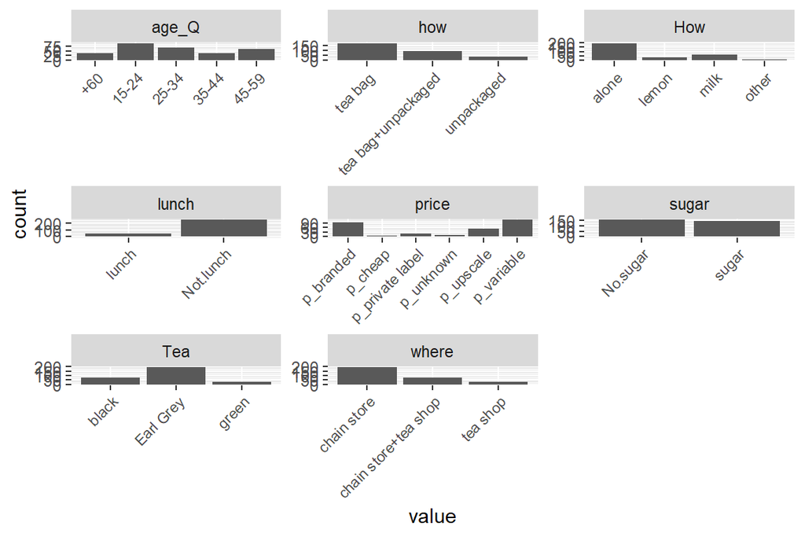

```r
# visualize the dataset
library(ggplot2)
pivot_longer(tea_time, cols = everything()) %>%
  ggplot(aes(value)) +
  facet_wrap("name", scales = "free") +
  geom_bar() + theme(axis.text.x = element_text(angle = 45, hjust = 1, size = 8))
```

A quick look into the data shows that the most common way to prepare tea is by tea bag and without any condiments (lemon, milk or other). Tea is usually consumed outside lunch hours. There’s a roughly 50-50 ratio of sugar users and the most common bought tea is Early Grey.

```r
#MCA
tea_mca <- MCA(tea_time, graph = FALSE)

#summary of model
summary(tea_mca)
```

```
##
## Call:
## MCA(X = tea_time, graph = FALSE)
##
##
## Eigenvalues
##                        Dim.1   Dim.2   Dim.3   Dim.4   Dim.5   Dim.6   Dim.7
## Variance               0.286   0.222   0.196   0.163   0.154   0.146   0.138
## % of var.             11.433   8.872   7.836   6.517   6.161   5.823   5.509
## Cumulative % of var.  11.433  20.305  28.141  34.658  40.819  46.642  52.151
##                        Dim.8   Dim.9  Dim.10  Dim.11  Dim.12  Dim.13  Dim.14
## Variance               0.128   0.123   0.118   0.113   0.109   0.107   0.101
## % of var.              5.134   4.919   4.727   4.527   4.379   4.269   4.054
## Cumulative % of var.  57.285  62.204  66.931  71.458  75.836  80.105  84.159
##                       Dim.15  Dim.16  Dim.17  Dim.18  Dim.19  Dim.20
## Variance               0.087   0.077   0.074   0.067   0.051   0.039
## % of var.              3.492   3.082   2.960   2.682   2.055   1.571
## Cumulative % of var.  87.651  90.733  93.693  96.375  98.429 100.000
##
## Individuals (the 10 first)
##                       Dim.1    ctr   cos2    Dim.2    ctr   cos2    Dim.3
## 1                  | -0.271  0.085  0.016 |  0.470  0.332  0.048 |  0.500
## 2                  | -0.030  0.001  0.000 |  0.206  0.064  0.023 |  0.769
## 3                  | -0.209  0.051  0.038 |  0.150  0.034  0.020 |  0.220
## 4                  | -0.564  0.371  0.334 | -0.063  0.006  0.004 | -0.261
## 5                  | -0.209  0.051  0.038 |  0.150  0.034  0.020 |  0.220
## 6                  | -0.605  0.427  0.154 |  0.314  0.148  0.041 |  0.001
## 7                  | -0.178  0.037  0.022 | -0.003  0.000  0.000 |  0.242
## 8                  |  0.001  0.000  0.000 |  0.053  0.004  0.001 |  0.790
## 9                  |  0.574  0.385  0.122 | -0.521  0.408  0.100 |  0.336
## 10                 |  0.809  0.764  0.251 | -0.392  0.231  0.059 |  0.538
##                       ctr   cos2
## 1                   0.425  0.054 |
## 2                   1.006  0.318 |
## 3                   0.083  0.043 |
## 4                   0.116  0.072 |
## 5                   0.083  0.043 |
## 6                   0.000  0.000 |
## 7                   0.099  0.040 |
## 8                   1.062  0.287 |
```

[output cut: 22 more lines]

```
## other               -4.015 |   2.596  12.896   0.208   7.893 |
## tea bag              6.987 |   0.213   1.640   0.059   4.211 |
## tea bag+unpackaged -11.514 |  -0.143   0.409   0.009  -1.670 |
## unpackaged           5.781 |  -0.632   3.063   0.055  -4.038 |
##
## Categorical variables (eta2)
##                      Dim.1 Dim.2 Dim.3
## Tea                | 0.162 0.111 0.326 |
## How                | 0.050 0.084 0.311 |
## how                | 0.526 0.474 0.080 |
## sugar              | 0.076 0.001 0.176 |
## where              | 0.638 0.574 0.145 |
## lunch              | 0.001 0.107 0.042 |
## price              | 0.562 0.348 0.035 |
## age_Q              | 0.271 0.075 0.451 |
```

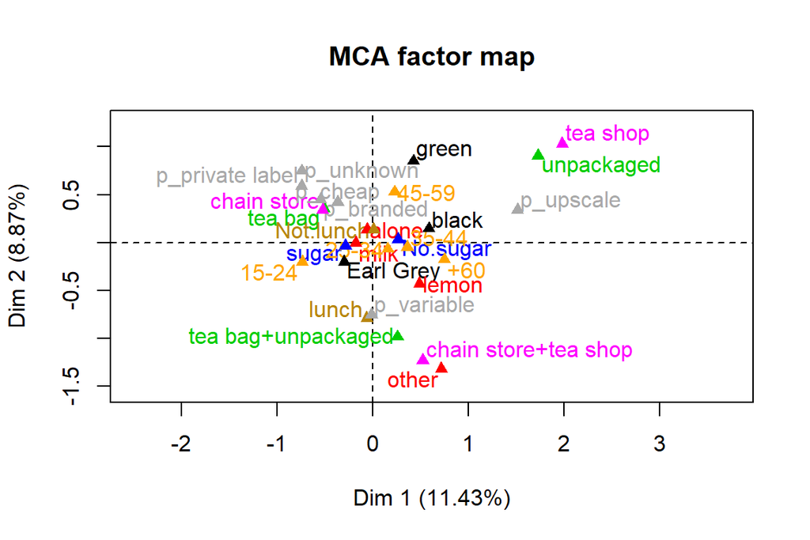

```r
#visualize model
plot(tea_mca, invisible=c("ind"), habillage = "quali", graph.type = "classic")
```

```r
library(factoextra)
```

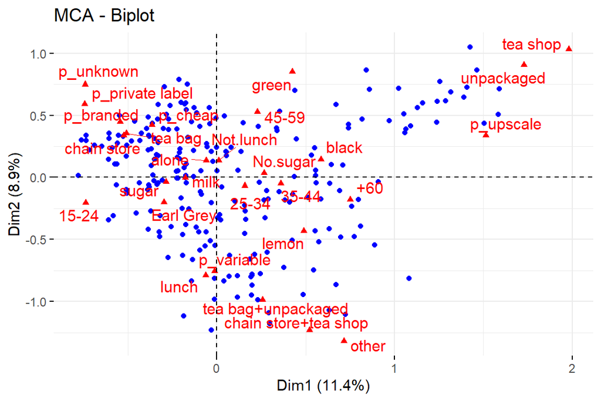

```r
fviz_mca_biplot(tea_mca,
               repel = TRUE,
               label = c("var", "quali.sup", "quanti.sup"),
               ggtheme = theme_minimal())
```

With the chosen variables it’s a bit hard to differentiate tea consumers from each other. There is, however, a clear cluster of p_upscale, unpackaged and tea shop from rest of the tea consumers.

# Assignment 6: Analysis of longitudinal data

This week we’ll look into data that will include two types of dependencies simultaneously. On toop of correlated variables we have observation data points that will also be correlated with each other. To analyse this data we’ll use linear mixed effects models.

## Data wrangling

This week’s data wrangling exercise had us change convert dataset from wide format to long format. There were also some modifications to the original dataset such as converting integers to factorials and creating extra column from character to integer. More info of dataset formats can be found [here](https://www.statology.org/long-vs-wide-data/) and you can find this week’s data wrangling exercise named meet_and_repeat.R [from my repo as usual](https://github.com/jmlankinen/IODS-project/tree/master/data).

## Rats dataset analysis

The analysis consists of two different datasets and two different analyses. First we’ll look into rats dataset in which three rat groups were put on different diets and each animal’s body weight was recorded approximately weekly over a 9-week period.

### Formatting the dataset

We’ll transform the data into long form and extract day numbers in the style of data wrangling exercise

```r
rats <- read.table("https://raw.githubusercontent.com/KimmoVehkalahti/MABS/master/Examples/data/rats.txt", sep = '\t', header = T)
library(dplyr)
library(tidyr)

str(rats)
```

```
## 'data.frame':    16 obs. of  13 variables:
##  $ ID   : int  1 2 3 4 5 6 7 8 9 10 ...
##  $ Group: int  1 1 1 1 1 1 1 1 2 2 ...
##  $ WD1  : int  240 225 245 260 255 260 275 245 410 405 ...
##  $ WD8  : int  250 230 250 255 260 265 275 255 415 420 ...
##  $ WD15 : int  255 230 250 255 255 270 260 260 425 430 ...
##  $ WD22 : int  260 232 255 265 270 275 270 268 428 440 ...
##  $ WD29 : int  262 240 262 265 270 275 273 270 438 448 ...
##  $ WD36 : int  258 240 265 268 273 277 274 265 443 460 ...
##  $ WD43 : int  266 243 267 270 274 278 276 265 442 458 ...
##  $ WD44 : int  266 244 267 272 273 278 271 267 446 464 ...
##  $ WD50 : int  265 238 264 274 276 284 282 273 456 475 ...
##  $ WD57 : int  272 247 268 273 278 279 281 274 468 484 ...
##  $ WD64 : int  278 245 269 275 280 281 284 278 478 496 ...
```

```r
#16x13 with ID, groups and weekdays. Only integer variables.

# Factor treatment, subject, ID and groups
rats$ID <- factor(rats$ID)
rats$Group <- factor(rats$Group)

#Convert rats to long form
rats <-  pivot_longer(rats, cols = -c(ID, Group),
                      names_to = "WD", values_to = "Weight") %>%
  arrange(WD) #order by weekday variable

#Extract the day number
rats <-  rats %>%
  mutate(Time = as.integer(substr(WD, 3, 4)))


str(rats)
```

```
## tibble [176 × 5] (S3: tbl_df/tbl/data.frame)
##  $ ID    : Factor w/ 16 levels "1","2","3","4",..: 1 2 3 4 5 6 7 8 9 10 ...
##  $ Group : Factor w/ 3 levels "1","2","3": 1 1 1 1 1 1 1 1 2 2 ...
##  $ WD    : chr [1:176] "WD1" "WD1" "WD1" "WD1" ...
##  $ Weight: int [1:176] 240 225 245 260 255 260 275 245 410 405 ...
##  $ Time  : int [1:176] 1 1 1 1 1 1 1 1 1 1 ...
```

```r
#176x5 tibble with factorial ID's and groups. Character day and integer weight (grams) & time (day).
```

We’ve now turned the dataset from 16x13 wide format into 176x5 “tibble”/long format.